# ggplot

```r
# load-packages
library(tidyverse)
```

## Online books

[ggplot2 - Hadley Wickham](https://ggplot2-book.org/)

[Fundamentals of Data Visualization - Claus O. Wilke](https://serialmentor.com/dataviz/)

## hjust and vjust

Why do I always forget the direction of these?

[Visual Example - R-bloggers](https://www.r-bloggers.com/hjust-and-vjust/)

## Math Expressions in labels

### Use `quote()`

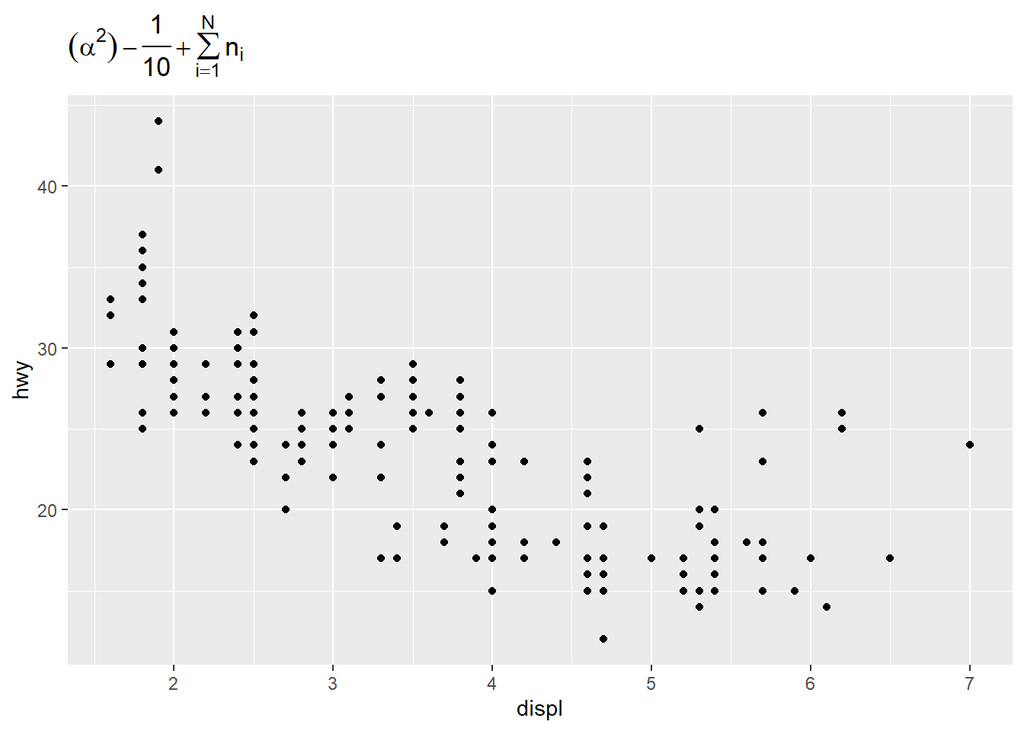

```r
ggplot(mpg, aes(displ, hwy))+geom_point()+
  ggtitle(
    quote(
      (alpha ^ 2) - frac(1, 10) + sum(n[i], i==1, N)
                )
    )
```

### Use `TeX()` from the `latex2exp` package

- must be in a string
- must be denoted as math mode with dollar signs
- must include **2** backslashes for $\LaTeX$ commands

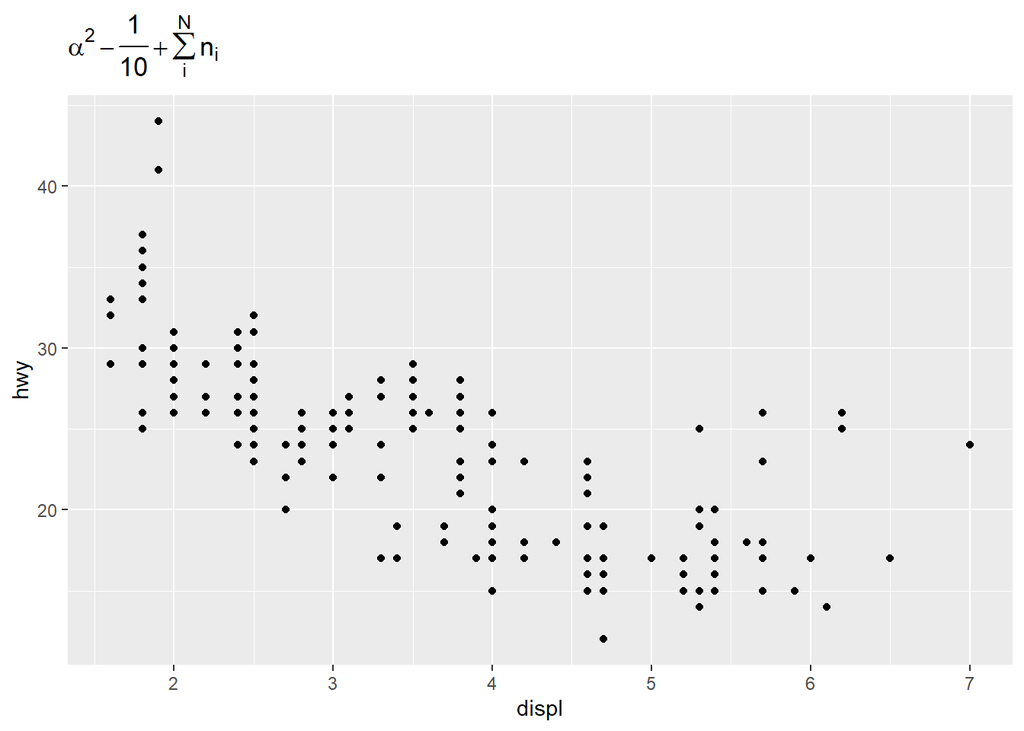

```r
library(latex2exp)
ggplot(mpg, aes(displ, hwy))+geom_point()+
  ggtitle(TeX(
    "$\\alpha^2 - \\frac{1}{10} + \\sum_{i}^N n_i$"
                )
    )
```

## Laying out multiple plots

[Laying out multiple plots on a page - Baptiste Auguie](https://cran.r-project.org/web/packages/egg/vignettes/Ecosystem.html)

## Line up axes on stacked plots

Sometimes I’m working on two different types of plots (like a bar chart and a scatter plot) that happen to have the same x-axis. I want to line up these axes so that when the plots are stacked the values correspond to the same date.

### Same geom type

```r
# two different bar charts
A <- ggplot(mpg, aes(class))+geom_bar()+coord_flip()+ylim(0, 109)
B <- ggplot(mpg, aes(drv))+geom_bar()+coord_flip()+ylim(0, 109)
```

Using `grid.arrange` command from the `gridExtra` package does not line up axes.

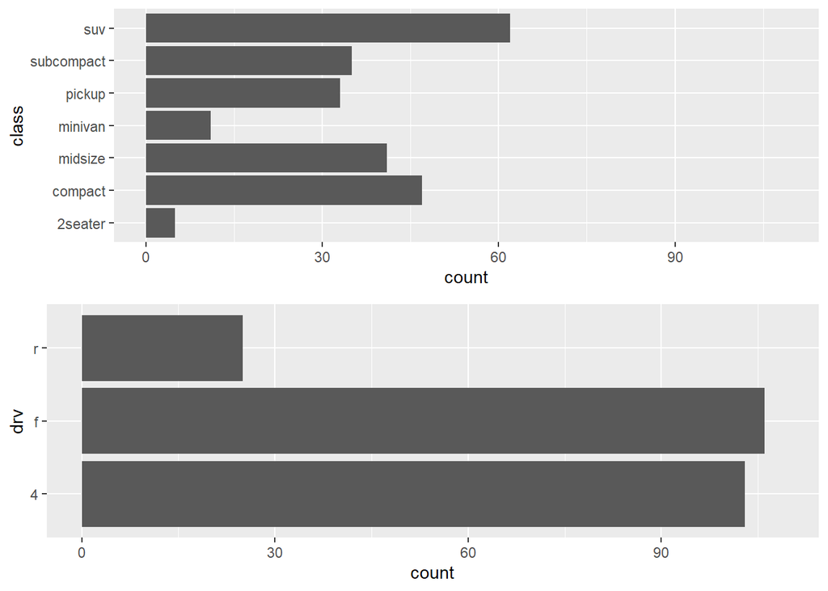

```r
#axes don't line up
gridExtra::grid.arrange(A, B, ncol=1)
```

Use `grid.draw` command from the `grid` package.  
[Source](https://stackoverflow.com/questions/13294952/left-align-two-graph-edges-ggplot)

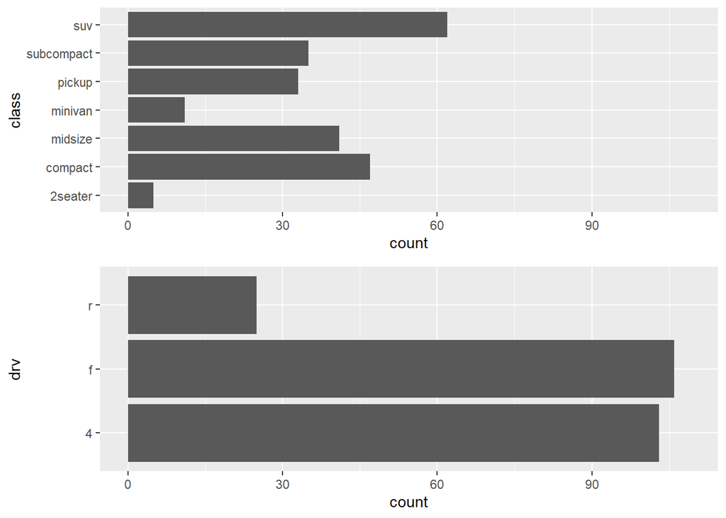

```r
#make plots into Grobs (grid graphical object)
gA <- ggplotGrob(A)
gB <- ggplotGrob(B)
grid::grid.draw(rbind(gA, gB))
```

Another option is `facet_wrap`, which works great if the axes are the same for the different varaibles you want to compare, but isn’t a perfect solution to everything (see below).

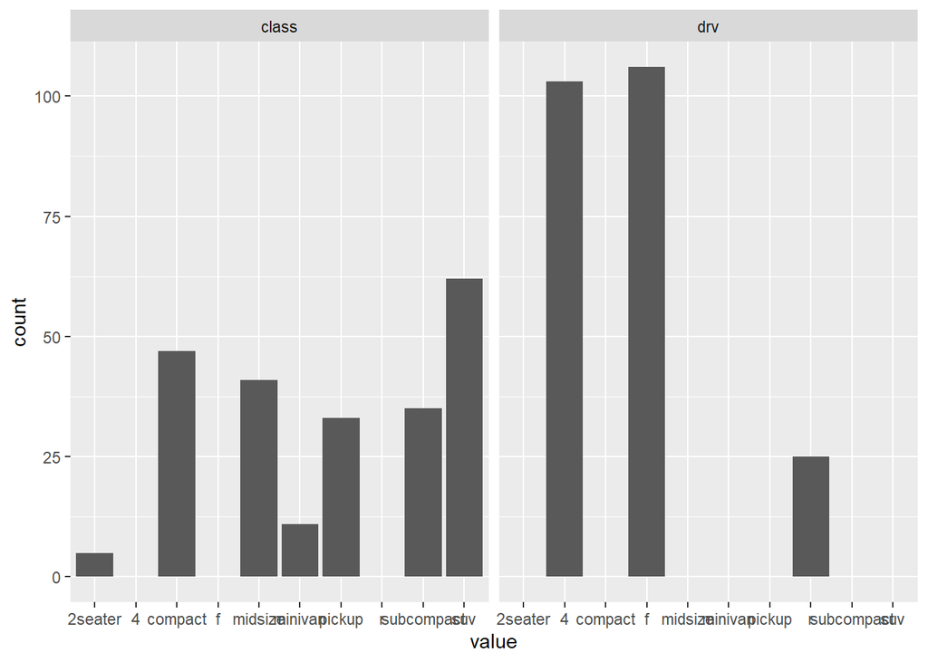

```r
tidy.df <- pivot_longer(mpg, c(class, drv))
ggplot(tidy.df, aes(value))+geom_bar()+facet_wrap(~name)
```

### Bar Chart and Scatter Plots

Scatter plots and bar charts will not line up automatically, even when using the `grid.draw` command detailed above. This is because their default limits are different given that the bar chart is centered on the value and the scatter plot is a single point on the value.

```r
#work with smaller subset of data from economics, part of ggplot2 package
startdate <- "2014-06-01"
economics_small <- economics %>%
  filter(date >= as.Date(startdate)) %>%
  arrange(date)
```

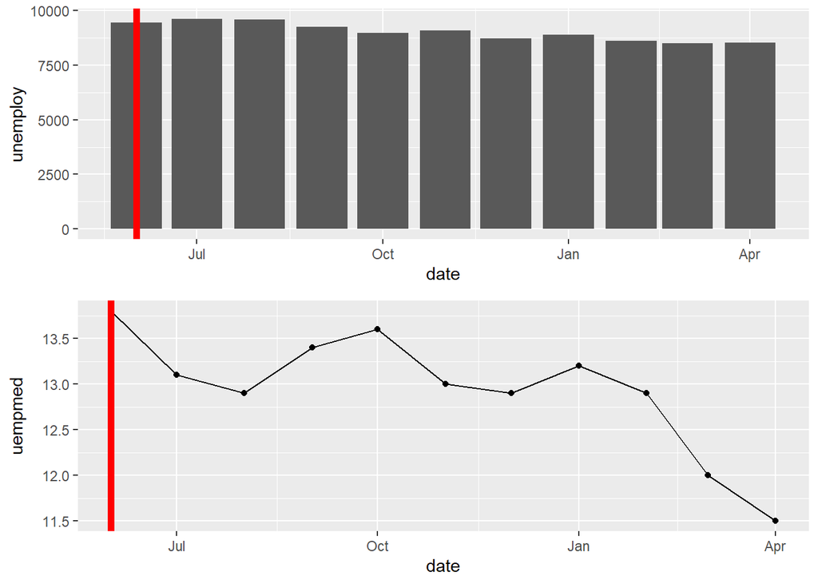

```r
A <- ggplot(economics_small, aes(date, unemploy))+
  geom_bar(stat="identity")+
  geom_vline(xintercept = as.Date(startdate), color="red", size=2)

B <- ggplot(economics_small, aes(date, uempmed))+
  geom_point()+geom_line()+
  geom_vline(xintercept = as.Date(startdate), color="red", size=2)

gA <- ggplotGrob(A)
gB <- ggplotGrob(B)
grid::grid.draw(rbind(gA, gB))
```

In order to line the up there a a couple of options.

#### Fix xlim for all charts

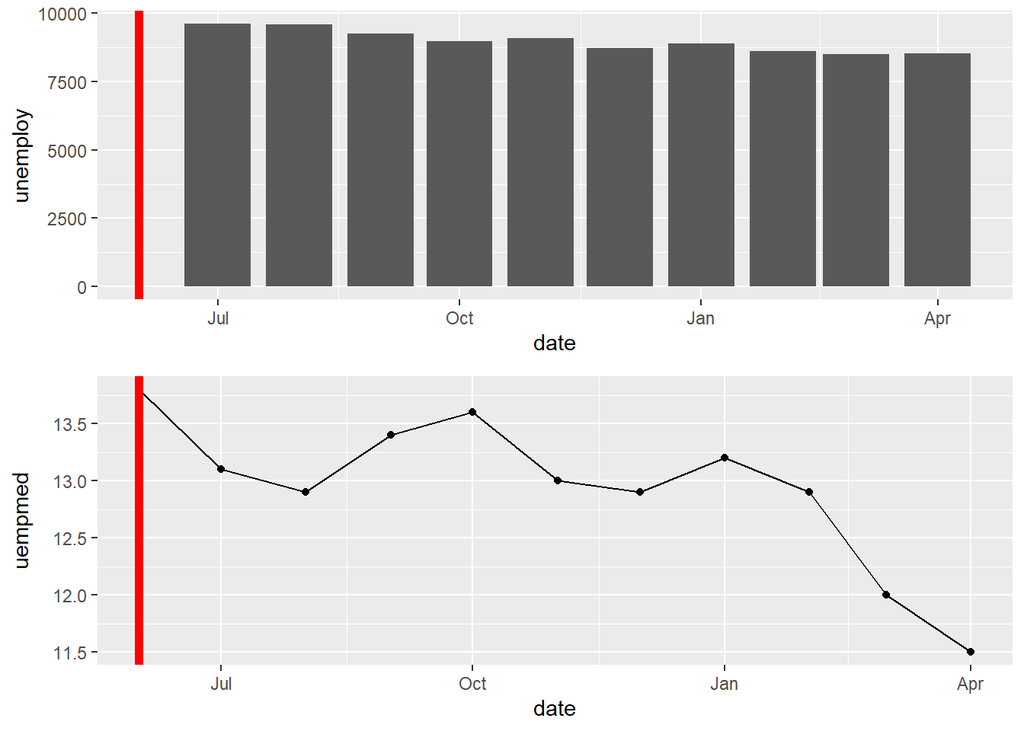

```r
A <- ggplot(economics_small, aes(date, unemploy))+
  geom_bar(stat="identity")+
  geom_vline(xintercept = as.Date(startdate), color="red", size=2)+
  xlim(as.Date(startdate), NA)

B <- ggplot(economics_small, aes(date, uempmed))+
  geom_point()+geom_line()+
  geom_vline(xintercept = as.Date(startdate), color="red", size=2)+
  xlim(as.Date(startdate), NA)

gA <- ggplotGrob(A)
gB <- ggplotGrob(B)
grid::grid.draw(rbind(gA, gB))
```

This can be fixed by adding a half unit to the x-axis (i.e. having the lower limit be half-unit lower than smallest x-value). In this case the unit is a month, so a half-unit would be ~15 days.

```r
HalfUnit <- .5*(economics_small$date[2] - economics_small$date[1])
HalfUnit
```

```
## Time difference of 15 days
```

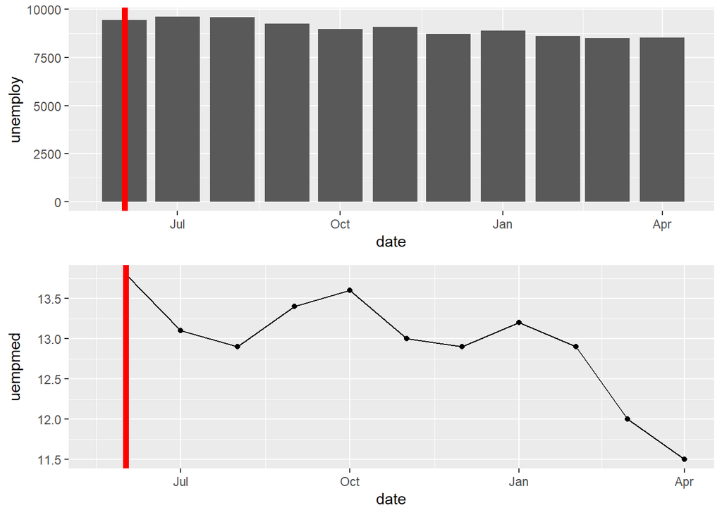

```r
A <- ggplot(economics_small, aes(date, unemploy))+
  geom_bar(stat="identity")+
  geom_vline(xintercept = as.Date(startdate), color="red", size=2)+
  xlim(as.Date(startdate)-HalfUnit, NA)

B <- ggplot(economics_small, aes(date, uempmed))+
  geom_point()+geom_line()+
  geom_vline(xintercept = as.Date(startdate), color="red", size=2)+
  xlim(as.Date(startdate)-HalfUnit, NA)

gA <- ggplotGrob(A)
gB <- ggplotGrob(B)
grid::grid.draw(rbind(gA, gB))
```

### Shift Bar chart to right

Bar charts are automatically centered over the x-value. Bar charts (and any geom object) can be shifted by using `position - position_nudge())`. The shift needs to be half a unit on the x-axis, again here it is monthly data so a half unit would be ~15 days.  
[Source](https://stackoverflow.com/questions/38752968/shift-geom-bar-right-not-center-aligned)

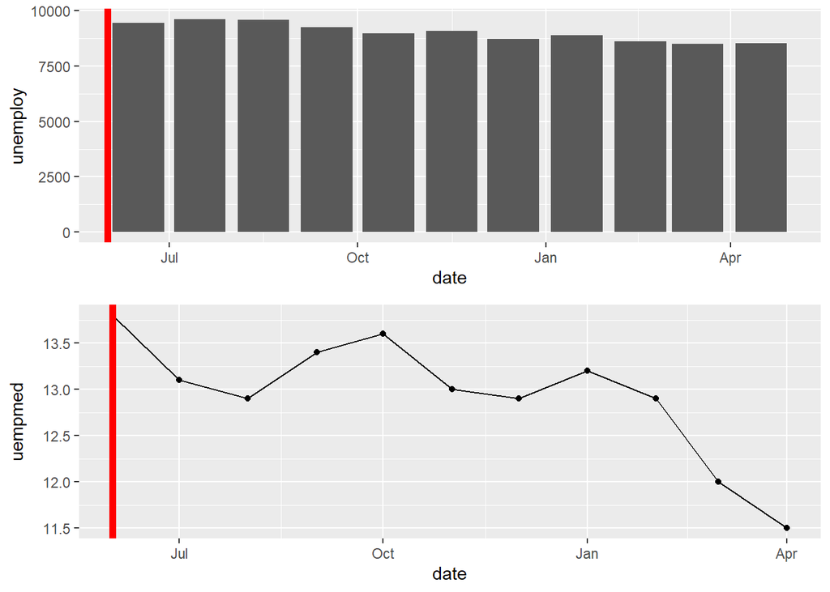

```r
A <- ggplot(economics_small, aes(date, unemploy))+
  geom_bar(stat="identity", position = position_nudge(x = HalfUnit))+
  geom_vline(xintercept = as.Date(startdate), color="red", size=2)

B <- ggplot(economics_small, aes(date, uempmed))+
  geom_point()+geom_line()+
  geom_vline(xintercept = as.Date(startdate), color="red", size=2)

gA <- ggplotGrob(A)
gB <- ggplotGrob(B)

grid::grid.draw(rbind(gA, gB))
```